# Distributions and Statistics

Up to now, the emphasis has been on individual cases. Data graphics, for instance, translate each case into a representation in terms of a glyph’s graphical attributes: position, color, size, shape, etc.

There are many occasions where a different emphasis is called for: representing the collective properties of cases. You’ve seen simple collective properties calculated with *summary functions*: mean, median, max, etc. The concern here is detailed collective descriptions, aspects of the collective that cannot be summed up in a single number.

## Distribution of a variable

To start, consider the `weight` variable in the `NHANES` data. Of course, weight varies from person to person; there is a **distribution** of weights from case to case.

Sometimes it’s helpful to show this distribution, what values are common, what values are rare, what values never show up.

### Density

Naïvely, this might be done by drawing a weight axis and putting on it a point for each case:

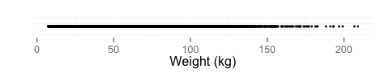

This graph shows some familiar facts: humans tend not to be lighter than a few kilograms, and tend not to be heavier than about 150 kg. Between these limits, there seems to be no detail.

This is misleading, the result of having so many cases (29375) to plot. All those cases lead to ink saturation. One way to overcome this problem is by using transparency, another is to *jitter* the individual points. The result is this:

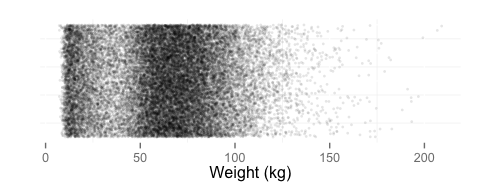

This is a much more satisfactory display; the ink saturation has been greatly reduced and now detail in the distribution of weights can be seen. For instance, the most common weights are between 55 and 90 kg, and that weights less than 20 kg are also pretty common. There aren’t so many people with weights near 30kg, and very few over 120 kg.

The visual impression is due to collective properties of the data. Every individual glyph is identical, but for weights where the glyphs are densely packed, the impression the glyphs collectively give is of darkness. Unfortunately, people are not very good at comparing different levels of darkness.

The collective property of density is conventionally displayed as a another kind of glyph that displays the collective density property using position instead of darkness, like this:

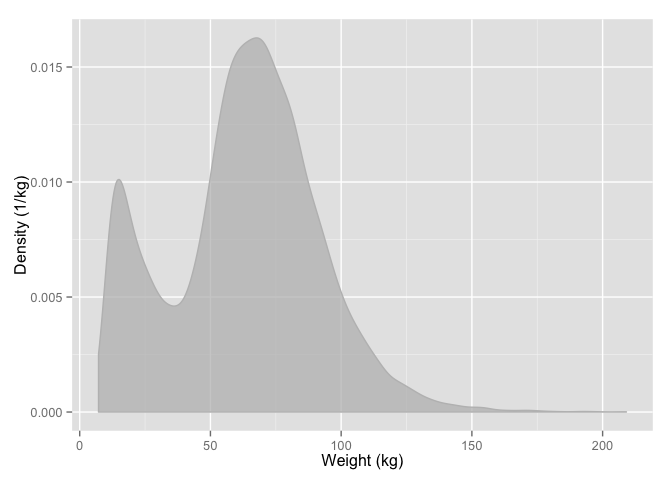

```r
ggplot( NHANES, aes(x=weight) ) +
  geom_density(color="gray", fill="gray", alpha=.75) +
  xlab("Weight (kg)") + ylab( "Density (1/kg)")
```

In this format, the *height* of the band indicates the density of cases. You can’t see individual cases, just the collective property of the density at each weight.[^1]

To help see the translation between the density as vertical position and the density as darkness, here is an unusual graph format that combines both.

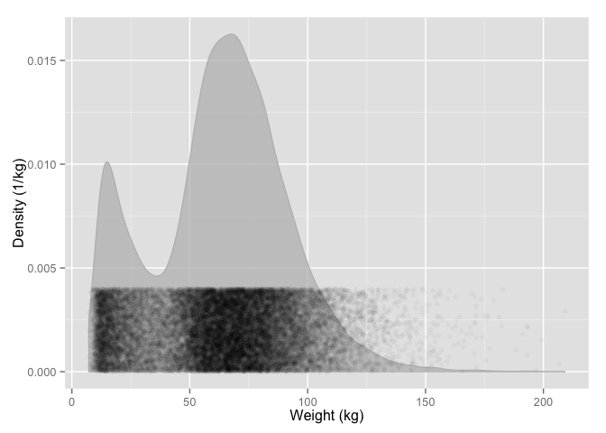

Density glyphs can be used to compare distributions for different groups. You need merely indicate which variable should be used for grouping. For instance, here are the densities of body weight for each sex:

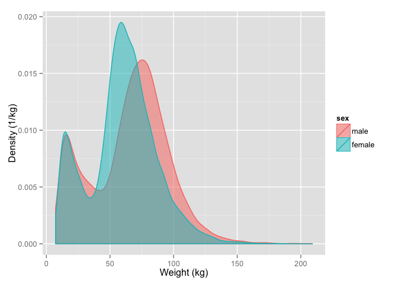

```r
ggplot( NHANES, aes(x=weight, group=sex) ) +
  geom_density(aes(color=sex, fill=sex), alpha=.5) +
  xlab("Weight (kg)") + ylab( "Density (1/kg)")
```

The density shows detail, but is often a fairly simple shape. This allows you to place densities side by side for comparison. For instance, here people are being divided into different age groups.

```r
NHANES <-
  NHANES %>%
  mutate( ageGroup=
      ntiles(age, n=6, format="interval") )
```

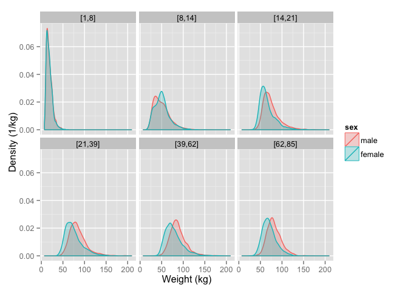

```r
NHANES %>%
  ggplot( aes(x=weight, group=sex) ) +
  geom_density(aes(color=sex, fill=sex), alpha=.25) +
  xlab("Weight (kg)") + ylab( "Density (1/kg)") +
  facet_wrap( ~ ageGroup )
```

As always, the best choice of a mapping between variables and graphical attributes depends on what aspect of the data you would like to emphasize. For instance, to see how weight changes with age, you might prefer to use `sex` as the faceting variable and `age` as the grouping variable.

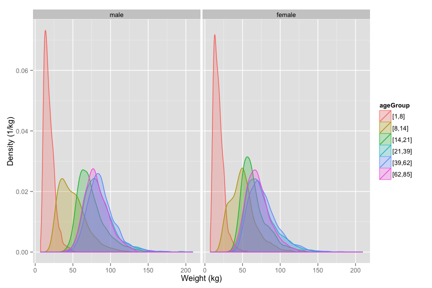

```r
NHANES %>%
  ggplot( aes(x=weight, group=ageGroup) ) +
  geom_density(aes(color=ageGroup, fill=ageGroup), alpha=.25) +
  xlab("Weight (kg)") + ylab( "Density (1/kg)") +
  facet_wrap( ~ sex )
```

### Simple depictions of distribution

The detail in the density curves can be visually overwhelming: there’s a lot of detail in each density curve. To simplify the graph, sometimes a more stylized depiction of the distribution is helpful. This makes it feasible to put the distributions side-by-side for comparison. The most common such depiction is the *box and whisker* glyph.

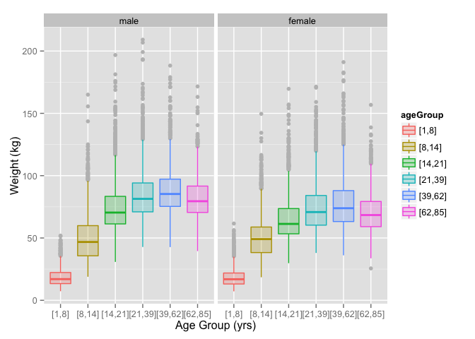

```r
NHANES %>%
  ggplot( aes(y=weight, x=ageGroup ) ) +
  geom_boxplot(
    aes(color=ageGroup, fill=ageGroup),
    alpha=.25, outlier.size=2, outlier.colour="gray") +
  ylab("Weight (kg)") + xlab( "Age Group (yrs)") +
  facet_wrap( ~ sex )
```

The box-and-whisker glyph shows the extent of the middle 50% of the distribution as a box. The whiskers show the range of the top and bottom quarter of the distribution. When there are uncommon, extremely high or low values — called “outliers” — they are displayed as individual dots for each of the outlier cases.

The *violin* glyph provides a similar ease of comparison to the box-and-whisker glyph, but shows more detail in the density.

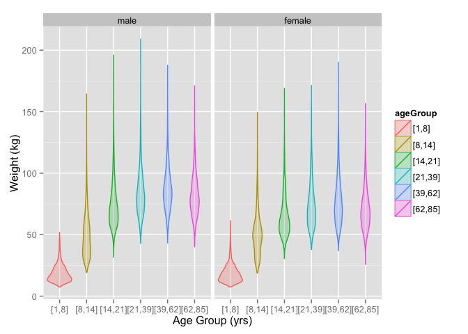

```r
NHANES %>%
  ggplot( aes(y=weight, x=ageGroup) ) +
  geom_violin( aes(color=ageGroup, fill=ageGroup),
    alpha=.25, outlier.size=1) +
  ylab("Weight (kg)") + xlab( "Age Group (yrs)") +
  facet_wrap( ~ sex )
```

Both the box-and-whisker and violin glyphs use ink very efficiently. This allows you to show other data. For instance, here’s the same box-and-whisker plot, but with people with diabetics shown in red.

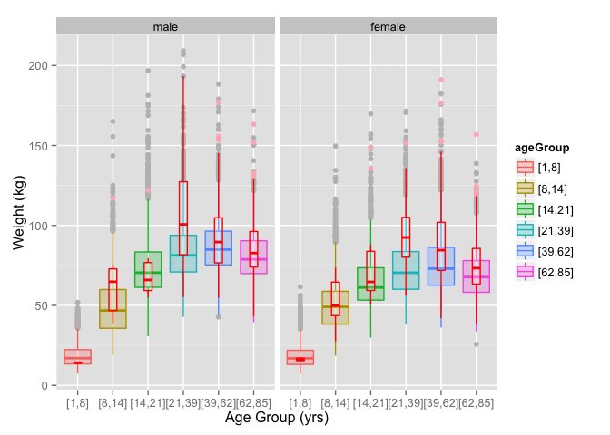

```r
Diabetics <-
  NHANES %>% filter( diabetic=="Diabetic" )
Nondiabetics <-
  NHANES %>% filter( diabetic=="Not" )
Nondiabetics %>%
  ggplot( aes(y=weight, x=ageGroup) ) +
  geom_boxplot(
    aes(color=ageGroup, fill=ageGroup),
    alpha=.25, outlier.size=2, outlier.colour="gray") +
  ylab("Weight (kg)") + xlab( "Age Group (yrs)") +
  facet_wrap( ~ sex ) +
  geom_boxplot( data=Diabetics, width=.3,color='red',
                outlier.colour="lightpink",alpha=.2)
```

You can see that diabetics tend to be heavier than non-diabetics, especially for ages 19+.

## Confidence Intervals

Statistical inference refers to an assessment of the *strength* of evidence for a claim. For instance, in interpreting the plot above, it was claimed that diabetics tend to be heavier than non-diabetics. Perhaps this is just an accident. Might it be that there are so few diabetics that their weight distribution is not well known?

The *confidence interval* of a statistic tells how much uncertainty there is due to the size of the sample. Smaller-sized samples provide weaker evidence and their confidence intervals are longer than produced by larger-sized samples.

A box-and-whiskers glyph can show the confidence interval of the median by means of a “notch”. Overlap between the notches in two boxes indicates that the evidence for a difference is weak.

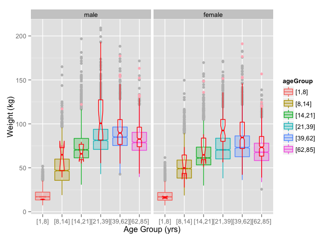

```r
Nondiabetics %>%
  ggplot( aes(y=weight, x=ageGroup) ) +
  geom_boxplot(
    aes(color=ageGroup, fill=ageGroup),
    alpha=.25, outlier.size=2, notch=TRUE,
    outlier.colour="gray") +
  ylab("Weight (kg)") + xlab( "Age Group (yrs)") +
  facet_wrap( ~ sex ) +
  geom_boxplot( data=Diabetics, width=.3,
                color='red',
                outlier.colour="lightpink",
                alpha=.2, notch=TRUE )
```

## Model Functions

A *function* is one way of describing a relationship between input and output. Often it’s helpful to use a function estimated from data.

For example, consider the relationship between weight and age in the NHANES data. Is it the same for diabetics and non-diabetics?

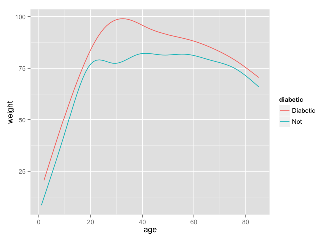

```r
NHANES %>%
  ggplot( aes(x=age, y=weight, color=diabetic ) ) +
  stat_smooth(se=FALSE )
```

There are two functions here, calculated by `stat_smooth()` from the age and weight variables. One function is for diabetics, the other for non-diabetics. Each function gives just one weight value for each age, rather than the distribution seen in the raw data. That value is[^2] the mean weight at each age. From the functions, it seems that the diabetics are consistently heavier than the non-diabetics, at least on average. At age 30, that average difference is more than 20kg, less for people near 80.

The confidence interval will show the precision of the function. This is so important to interpreting the graphic that the default in `stat_smooth()` is to calculate and show the confidence interval unless the user specifically asks not to.

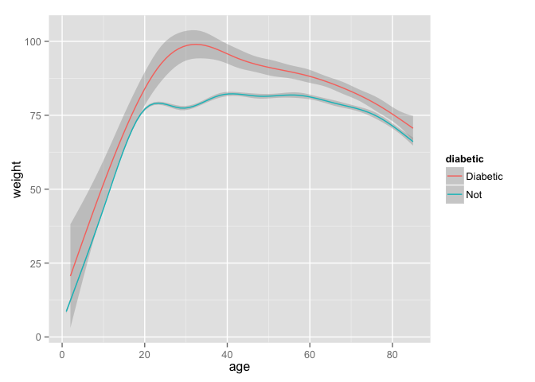

```r
NHANES %>%
  ggplot( aes(x=age, y=weight, color=diabetic ) ) +
  stat_smooth( )
```

The function for non-diabetics has a narrow confidence interval; you have to look hard to even see the gray zone. The confidence interval for diabetics, however, is noticeably wide. For ages below about 20, the non-diabetic and diabetic confindence intervals overlap. This means that there is only weak evidence that diabetics as a group in this age group differ in weight from non-diabetics. Around age 20, the two functions’ confidence intervals do not overlap. This indicates stronger evidence that the groups in the 20+ age bracket do differ in average weight.

You might ask, why the confidence interval for the diabetics is so much wider than for the non-diabetics? And why is the diabetic confidence interval broad in some places and narrow in others?

The width of a confidence interval depends on three things:

- the amount of variation in the value of y at or near the x value.
- the number of cases close to the x value
- the extent to which the function is an extrapolation.

You can see all these things by plotting out the individual cases in another graphical layer.

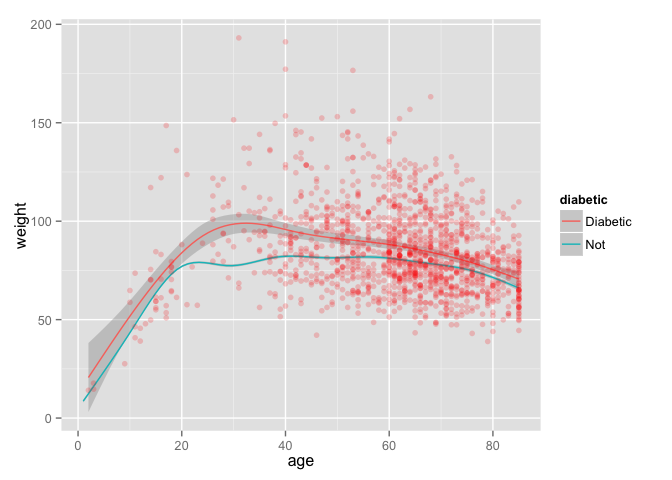

```r
NHANES %>%
  ggplot( aes(x=age, y=weight, color=diabetic ) ) +
  stat_smooth( ) +
  geom_point( data=Diabetics, color="red", alpha=.2)
```

There are only a handful of cases with age less than 20, and hardly any with age less than 10: that’s why the confidence interval for diabetics is wide there. On the other hand, there are lots of cases for age greater than 60.

This sort of function, called a “smoother”, is able to bend with the data. A much more commonly used function — the “linear” function — is utterly stiff; it can’t bend at all. You can construct this sort of function from the data with `method=lm` as an argument to `stat_smooth()`.

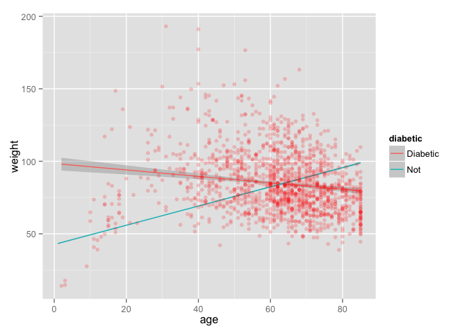

```r
NHANES %>%
  ggplot( aes(x=age, y=weight, color=diabetic ) ) +
  stat_smooth( method=lm ) +
  geom_point( data=Diabetics, color="red", alpha=.2)
```

You’ll often see linear functions in the scientific literature. This is for several reasons, some good and some bad:

- Linear functions generally have tighter confidence intervals than smoothers. (A good reason)
- People are familiar with straight-line functions from high school. (A bad reason)
- Many people don’t know about non-linear functions such as a smoother. (A bad reason)

A simple rule of thumb: When in doubt, use a smoother.

Please use the comment system to make suggestions, point out errors, or to discuss the topic.

[comments powered by Disqus](http://disqus.com)

Written by Daniel Kaplan for the Data & Computing Fundamentals Course. Development was supported by grants from the National Science Foundation for Project Mosaic (NSF DUE-0920350) and from the Howard Hughes Medical Institute.

[^1]: The scale of the y axis may seem odd; it has units of “inverse kilograms.” This scale is arranged so that the area under the entire density curve is 1. This convention facilitates densities for different groups, e.g. male versus female. It also means that narrow distributions tend to have high density.
[^2]: Roughly. The function is smoothed over a range of close ages.